# Covid19inSpain

## **COVID-19 Situation in Spain**

## Libraries

```python
%%time
!apt update
!apt upgrade
!apt install gdal-bin python-gdal python3-gdal
# Install rtree - Geopandas requirment
!apt install python3-rtree
# Install Geopandas
!pip install git+git://github.com/geopandas/geopandas.git
# Install descartes - Geopandas requirment
!pip install descartes
```

[output not shown]

```
  Cloning git://github.com/geopandas/geopandas.git to c:\users\trupti\appdata\local\temp\pip-req-build-94eipf11
  Using cached https://files.pythonhosted.org/packages/ea/55/61a5d274a210585b5d0c3dac81a82952a4baa7903e3642228d7a465fc340/Shapely-1.7.0-cp37-cp37m-win_amd64.whl
  Using cached https://files.pythonhosted.org/packages/6d/42/f4a7cac53b28fa70e9a93d0e89a24d33e14826dad6644b699362ad84dde0/Fiona-1.8.13.post1.tar.gz
```

[output not shown]

```
Wall time: 1min 2s
```

```python
import pandas as pd
import numpy as np
import seaborn as sns
import matplotlib
import matplotlib.pyplot as plt
import plotly.express as px
import plotly.offline as py
import plotly.graph_objs as go
import plotly.io as pio
py.offline.init_notebook_mode(connected=True)
import seaborn as sns
import geopandas as gpd
import os
import folium
import gc
from folium.plugins import TimeSliderChoropleth
from scipy.signal import find_peaks
import warnings
warnings.filterwarnings("ignore")
```

```python
from IPython.display import HTML

HTML('''<script>
code_show=true;
function code_toggle() {
 if (code_show){
 $('div.input').hide();
 } else {
 $('div.input').show();
 }
 code_show = !code_show
}
$( document ).ready(code_toggle);
</script>
<form action="javascript:code_toggle()"><input type="submit" value="Click here to toggle on/off the raw code."></form>''')
```

In this kernel I will focus on data visualization using mainly Plotly Express and Choropleth. The data source is the official website from the Spanish government for Covid-19 which is updated every 24 hours.

IMPORTANT NOTE: the way the Spanish government has dealed with the data has been changing during the last month (the introduced new variables, missing values, delimiter changes from one day to the next...). That means the dataset published by the government may change in the future and may appear some errors in the kernel.

In that case I will ty to fix it as soon as possible.

## Data loading and general overview

First, we will load the csv file from the offical Spanish goverment site which as we said is updated every 24 hours.

Spanish government website (updated every 24 hours) The data can be automatically downloaded from the link below and will be saved in our dataframe called data.

```python
data = pd.read_csv("https://covid19.isciii.es/resources/serie_historica_acumulados.csv",delimiter=",", encoding="latin1", skiprows=range(1730,1739))
```

```python
print(data.head())
print(data.tail(10))
```

```
  CCAA      FECHA  CASOS  PCR+  TestAc+  Hospitalizados  UCI  Fallecidos
0   AN  20/2/2020    0.0     0      NaN             NaN  NaN         NaN
1   AR  20/2/2020    NaN     0      NaN             NaN  NaN         NaN
2   AS  20/2/2020    NaN     0      NaN             NaN  NaN         NaN
3   IB  20/2/2020    NaN     1      NaN             NaN  NaN         NaN
4   CN  20/2/2020    NaN     1      NaN             NaN  NaN         NaN
     CCAA      FECHA  CASOS   PCR+  TestAc+  Hospitalizados     UCI  \
1719   CE  20/5/2020    NaN    119     59.0            11.0     4.0
1720   VC  20/5/2020    NaN  10987   3810.0          5747.0   730.0
1721   EX  20/5/2020    NaN   3042   1001.0          1780.0   110.0
1722   GA  20/5/2020    NaN   9077   2026.0          2943.0   334.0
1723   MD  20/5/2020    NaN  67049   5293.0         42497.0  3617.0
1724   ML  20/5/2020    NaN    121     13.0            44.0     3.0
1725   MC  20/5/2020    NaN   1570   1039.0           680.0   112.0
1726   NC  20/5/2020    NaN   5195   3157.0          2048.0   136.0
1727   PV  20/5/2020    NaN  13421   5358.0          7032.0   578.0
1728   RI  20/5/2020    NaN   4033   1395.0          1504.0    91.0

      Fallecidos
1719         4.0
1720      1383.0
1721       505.0
1722       608.0
1723      8931.0
1724         2.0
1725       149.0
1726       506.0
1727      1483.0
1728       354.0
```

```python
data.tail()
```

|  | CCAA | FECHA | CASOS | PCR+ | TestAc+ | Hospitalizados | UCI | Fallecidos |
| --- | --- | --- | --- | --- | --- | --- | --- | --- |
| 1724 | ML | 20/5/2020 | NaN | 121 | 13.0 | 44.0 | 3.0 | 2.0 |
| 1725 | MC | 20/5/2020 | NaN | 1570 | 1039.0 | 680.0 | 112.0 | 149.0 |
| 1726 | NC | 20/5/2020 | NaN | 5195 | 3157.0 | 2048.0 | 136.0 | 506.0 |
| 1727 | PV | 20/5/2020 | NaN | 13421 | 5358.0 | 7032.0 | 578.0 | 1483.0 |
| 1728 | RI | 20/5/2020 | NaN | 4033 | 1395.0 | 1504.0 | 91.0 | 354.0 |

```python
data.fillna(0)#missing values with 0
```

|  | CCAA | FECHA | CASOS | PCR+ | TestAc+ | Hospitalizados | UCI | Fallecidos |
| --- | --- | --- | --- | --- | --- | --- | --- | --- |
| 0 | AN | 20/2/2020 | 0.0 | 0 | 0.0 | 0.0 | 0.0 | 0.0 |
| 1 | AR | 20/2/2020 | 0.0 | 0 | 0.0 | 0.0 | 0.0 | 0.0 |
| 2 | AS | 20/2/2020 | 0.0 | 0 | 0.0 | 0.0 | 0.0 | 0.0 |
| 3 | IB | 20/2/2020 | 0.0 | 1 | 0.0 | 0.0 | 0.0 | 0.0 |
| 4 | CN | 20/2/2020 | 0.0 | 1 | 0.0 | 0.0 | 0.0 | 0.0 |
| ... | ... | ... | ... | ... | ... | ... | ... | ... |
| 1724 | ML | 20/5/2020 | 0.0 | 121 | 13.0 | 44.0 | 3.0 | 2.0 |
| 1725 | MC | 20/5/2020 | 0.0 | 1570 | 1039.0 | 680.0 | 112.0 | 149.0 |
| 1726 | NC | 20/5/2020 | 0.0 | 5195 | 3157.0 | 2048.0 | 136.0 | 506.0 |
| 1727 | PV | 20/5/2020 | 0.0 | 13421 | 5358.0 | 7032.0 | 578.0 | 1483.0 |
| 1728 | RI | 20/5/2020 | 0.0 | 4033 | 1395.0 | 1504.0 | 91.0 | 354.0 |

1729 rows × 8 columns

```python
#changing name of columns
data.rename(columns={"FECHA":"Date",
              "PCR+":"Infected",
             "Hospitalizados":"Hospitalized",
             "Fallecidos":"Deaths",
             "Recuperados":"Cured",
             "UCI":"ICU",
             "CASOS":"Cases"},inplace= True)
```

```python
data.replace({"AN":"Andalucía","AR":"Aragón","AS":"Asturias",
                "IB":"Baleares","CN":"Canarias","CB":"Cantabria",
                 "CM":"Castilla La Mancha","CL":"Castilla y León","CT":"Cataluña",
              "CE":"Ceuta","VC":"C. Valenciana","EX":"Extremadura","GA":"Galicia",
             "MD":"Madrid","ML":"Melilla","MC":"Murcia","NC":"Navarra",
             "PV":"País Vasco","RI":"La Rioja"},inplace=True)
```

```python
#convert the date values and create a new column called NEW_DATE.
data.Date = pd.to_datetime(data.Date, format="%d/%m/%Y")
```

```python
data["NEW_DATE"] = data.Date.apply(lambda x: x.strftime("%d %b, %Y"))
```

```python
print(data.Date.min())
print(data.Date.max())
```

```
2020-02-20 00:00:00
2020-05-20 00:00:00
```

```python
total_s = data.groupby(["Date","NEW_DATE"])["Date","Cases","Infected","TestAc+","Deaths","Hospitalized","ICU"].sum().reset_index()
total_s.head()
```

|  | Date | NEW_DATE | Cases | Infected | TestAc+ | Deaths | Hospitalized | ICU |
| --- | --- | --- | --- | --- | --- | --- | --- | --- |
| 0 | 2020-02-20 | 20 Feb, 2020 | 0.0 | 3 | 0.0 | 0.0 | 26.0 | 0.0 |
| 1 | 2020-02-21 | 21 Feb, 2020 | 0.0 | 3 | 0.0 | 0.0 | 30.0 | 1.0 |
| 2 | 2020-02-22 | 22 Feb, 2020 | 0.0 | 3 | 0.0 | 0.0 | 33.0 | 1.0 |
| 3 | 2020-02-23 | 23 Feb, 2020 | 0.0 | 3 | 0.0 | 0.0 | 38.0 | 2.0 |
| 4 | 2020-02-24 | 24 Feb, 2020 | 0.0 | 4 | 0.0 | 0.0 | 49.0 | 2.0 |

```python
#create variables with infectef & dead daily people
aux = total_s.Infected.to_list()

daily=[]

for i in range(len(aux)-1):
    b = aux[i+1] - aux[i]
    daily.append(b)

daily.insert(0,0)

total_s["Daily_Infected"] = daily
```

```python
aux = total_s.Deaths.to_list()

daily=[]

for i in range(len(aux)-1):
    b = aux[i+1] - aux[i]
    daily.append(b)

daily.insert(0,0)

total_s["Daily_Deaths"] = daily
```

```python
aux = total_s.Cases.to_list()

daily=[]

for i in range(len(aux)-1):
    b = aux[i+1] - aux[i]
    daily.append(b)

daily.insert(0,0)

total_s["Daily_Cases"] = daily
```

```python
total_s.head()
```

|  | Date | NEW_DATE | Cases | Infected | TestAc+ | Deaths | Hospitalized | ICU | Daily_Infected | Daily_Deaths | Daily_Cases |
| --- | --- | --- | --- | --- | --- | --- | --- | --- | --- | --- | --- |
| 0 | 2020-02-20 | 20 Feb, 2020 | 0.0 | 3 | 0.0 | 0.0 | 26.0 | 0.0 | 0 | 0.0 | 0.0 |
| 1 | 2020-02-21 | 21 Feb, 2020 | 0.0 | 3 | 0.0 | 0.0 | 30.0 | 1.0 | 0 | 0.0 | 0.0 |
| 2 | 2020-02-22 | 22 Feb, 2020 | 0.0 | 3 | 0.0 | 0.0 | 33.0 | 1.0 | 0 | 0.0 | 0.0 |
| 3 | 2020-02-23 | 23 Feb, 2020 | 0.0 | 3 | 0.0 | 0.0 | 38.0 | 2.0 | 0 | 0.0 | 0.0 |
| 4 | 2020-02-24 | 24 Feb, 2020 | 0.0 | 4 | 0.0 | 0.0 | 49.0 | 2.0 | 1 | 0.0 | 0.0 |

## Plotting

```python
aux = total_s.melt(id_vars="Date", value_vars=("Cases","Infected","TestAc+","Deaths","ICU","Hospitalized"), value_name="Count" , var_name= "Description")
aux.head()
```

|  | Date | Description | Count |
| --- | --- | --- | --- |
| 0 | 2020-02-20 | Cases | 0.0 |
| 1 | 2020-02-21 | Cases | 0.0 |
| 2 | 2020-02-22 | Cases | 0.0 |
| 3 | 2020-02-23 | Cases | 0.0 |
| 4 | 2020-02-24 | Cases | 0.0 |

```python
data_infected = data[data.Date>"20-02-2020"]
```

### Infections over time

```python
fig = px.bar(data_infected, x="CCAA", y="Infected", color="CCAA",
              animation_frame="NEW_DATE", animation_group="CCAA", range_y=[0,data.Infected.max()+1000],title= "Infections by regions over time")
fig.show()
```

[interactive chart not shown]

### Analysis of Madrid

Madrid was the region with the highest number of infections and deaths. In the following graphics we will analyze the different variables. The cases related to infections were collected in the variable PCR+ (Infected), we can just use that variable just for Madrid.

```python
total_madrid = data[data.CCAA=="Madrid"].groupby("Date")["Date","Infected","Deaths","Hospitalized","ICU"].sum().reset_index()
```

```python
aux_m = total_madrid.melt(id_vars="Date", value_vars=("Infected","Deaths","ICU","Hospitalized"), value_name="Count" , var_name= "Status")
```

```python
fig = px.bar(aux_m, x= "Date", y = "Count", color="Status", title= "Actual situation in Madrid")
fig.show()
```

[interactive chart not shown]

### Top 6 countries affected

```python
for i in data.CCAA.unique():

    a = i.replace(".","")
    a = a.replace(" ","_")

    exec('df_{}=data[data.CCAA == i]'.format(a))

    exec('aux_a = df_{}.Infected.to_list()'.format(a))


    daily=[]
    for i in range(len(aux_a)-1):
        b = aux_a[i+1] - aux_a[i]
        daily.append(b)

    daily.insert(0,0)

    exec('df_{}["Daily_infected"] = daily'.format(a))

    exec('aux_d = df_{}.Deaths.to_list()'.format(a))


    daily=[]
    for i in range(len(aux_d)-1):
        b = aux_d[i+1] - aux_d[i]
        daily.append(b)

    daily.insert(0,0)

    exec('df_{}["Daily_deaths"] = daily'.format(a))
```

```python
df_daily_infected = pd.DataFrame({"Date":data.Date.unique(),
                                 "Madrid":df_Madrid["Daily_infected"].values,
                                 "Cataluña":df_Cataluña["Daily_infected"].values,
                                 "Andalucia":df_Andalucía["Daily_infected"].values,
                                 "Castilla La Mancha":df_Castilla_La_Mancha["Daily_infected"].values,
                                 "Castilla y Leon":df_Castilla_y_León["Daily_infected"].values,
                                 "País Vasco":df_País_Vasco["Daily_infected"].values})
```

```python
aux_i = df_daily_infected.melt(id_vars="Date", value_vars=("Madrid","Cataluña","Andalucia","Castilla La Mancha","Castilla y Leon","País Vasco"), value_name="Count" , var_name= "CCAA")
```

#### Daily infections in Top 6 countries

```python
aux_1=aux_i[aux_i.Date>"20-02-2020"]
```

```python
aux_2=aux_i[aux_i.Date>"18-04-2020"]
fig = px.bar (aux_2, x= "Date", y = "Count", color="CCAA", title= "Daily infections in Spain (Top 6)")
fig.show()
```

[interactive chart not shown]

#### Daily deaths in Top 6 countries

```python
df_daily_fatalities = pd.DataFrame({"Date":data.Date.unique(),
                                 "Madrid":df_Madrid["Daily_deaths"].values,
                                 "Cataluña":df_Cataluña["Daily_deaths"].values,
                                 "Valencia":df_C_Valenciana["Daily_deaths"].values,
                                 "Castilla La Mancha":df_Castilla_La_Mancha["Daily_deaths"].values,
                                 "Castilla y Leon":df_Castilla_y_León["Daily_deaths"].values,
                                 "País Vasco":df_País_Vasco["Daily_deaths"].values})
```

```python
aux_f = df_daily_fatalities.melt(id_vars="Date", value_vars=("Madrid","Cataluña","Valencia","Castilla La Mancha","Castilla y Leon","País Vasco"), value_name="Count" , var_name= "CCAA")
```

```python
fig = px.line (aux_f, x= "Date", y = "Count", color="CCAA", title= "Daily Death in Spain (Top 6)")
fig.show()
```

[interactive chart not shown]

```python
fig = px.bar (aux_f, x= "Date", y = "Count", color="CCAA", title= "Daily Deaths in Spain (Top 6)")
fig.show()
```

[interactive chart not shown]

## Mapping with chloropleth

```python
d_name = {
'AN':'Andalucía',
'AR':'Aragón',
'AS':'Asturias',
'IB':'Baleares',
'CN':'Canarias',
'CB':'Cantabria',
'CM':'Castilla La Mancha',
'CL':'Castilla y León',
'CT':'Cataluña',
'CE':'Ceuta',
'VC':'C. Valenciana',
'EX':'Extremadura',
'GA':'Galicia',
'MD':'Madrid',
'ML':'Melilla',
'MC':'Murcia',
'NC':'Navarra',
'PV':'País Vasco',
'RI':'La Rioja'
}
```

```python
d_ccaa = {
'Andalucía': 'Andalucía',
'Aragón': 'Aragón',
'Asturias': 'Principado de Asturias',
'Baleares': 'Islas Baleares',
'Canarias': 'Islas Canarias',
'Cantabria':'Cantabria',
'Castilla La Mancha': 'Castilla-La Mancha',
'Castilla y León': 'Castilla y León',
'Cataluña': 'Cataluña',
'Ceuta': 'Ceuta y Melilla',
'C. Valenciana': 'Comunidad Valenciana',
'Extremadura': 'Extremadura',
'Galicia': 'Galicia',
'Madrid': 'Comunidad de Madrid',
'Melilla': 'Ceuta y Melilla',
'Murcia': 'Región de Murcia',
'Navarra': 'Comunidad Foral de Navarra',
'País Vasco': 'País Vasco',
'La Rioja': 'La Rioja'
}
```

```python
d_ccaa_id = {
'Andalucía': "1",
'Aragón' : "2",
'Principado de Asturias': "3",
'Islas Baleares': "4",
'Islas Canarias': "5",
'Cantabria': "6",
'Castilla-La Mancha': "7",
'Castilla y León': "8",
'Cataluña': "9",
'Ceuta y Melilla': "10",
'Comunidad Valenciana': "11",
'Extremadura': "12",
'Galicia': "13",
'Comunidad de Madrid' : "14",
'Ceuta y Melilla': "15",
'Región de Murcia': "16",
'Comunidad Foral de Navarra': "17",
'País Vasco': "18",
'La Rioja': "19"
}
```

```python
d_ccaa_population = {
'Andalucía': 8414240,
'Aragón' : 1319291,
'Principado de Asturias': 1022800,
'Islas Baleares': 1149460,
'Islas Canarias': 2153389,
'Cantabria': 581078,
'Castilla-La Mancha': 2032863,
'Castilla y León': 2399548,
'Cataluña': 7675217,
'Ceuta y Melilla': 171264,
'Comunidad Valenciana': 5003769,
'Extremadura': 1067710,
'Galicia': 2699499,
'Comunidad de Madrid' : 6663394,
'Ceuta y Melilla': 171264,
'Región de Murcia': 1493898,
'Comunidad Foral de Navarra': 654214,
'País Vasco': 2207776,
'La Rioja': 316798
}
```

```python
def get_hex_colors(df, data_to_color, cmap = matplotlib.cm.Reds, log = False):

    '''
    This function takes the following arguments
        1. df:pandas DataFrame with the data.
        2. data_to_color: the column name with data based on which we want to create the color scale.
        3. cmap: colors you want to plot. You can use this to communicate different messages. For example: greens --> good, greys --> deaths.
                default is matplotlib.cm.Reds
                more about colormaps: https://matplotlib.org/3.1.1/gallery/color/colormap_reference.html
        3. log: if data has huge outliers, we can create the color map with a logarithic normalization. This way, the outliers won't "pale" our other data.
                default is False.

    '''

    cmap = cmap # define the color pallete you want. You can use Reds, Blues, Greens etc
    my_values = df[data_to_color] # get the value you wan to convert to colors

    mini = min(my_values) # get the min to normalize
    maxi= max(my_values) # get the max to normalize

    LOGMIN = 0.01 # arbitrary lower bound for log scale

    if log:
        norm = matplotlib.colors.LogNorm(vmin=max(mini,LOGMIN), vmax=maxi) # normalize log data
    else:
        norm = matplotlib.colors.Normalize(vmin=mini, vmax=maxi) # create a color range

    colors = {value:matplotlib.colors.rgb2hex(cmap(norm(value))[:3]) for value in sorted(list(set(my_values)))} # create a dictionary with the total_infected or deaths as keys and colors as values

    return colors
```

```python
def get_hex_colors_2(value, cats):
    '''
    Color paletter used from this website:

    https://colorbrewer2.org/#type=sequential&scheme=Reds&n=9

    The color selection will be based on the percentile each value is in.
    '''
    if value == 0:
        return "#FFFFFF"
    elif value in cats[0]:
        return "#fff5f0"
    elif value in cats[1]:
        return "#fee0d2"
    elif value in cats[2]:
        return "#fcbba1"
    elif value in cats[3]:
        return "#fc9272"
    elif value in cats[4]:
        return "#fb6a4a"
    elif value in cats[5]:
        return "#ef3b2c"
    elif value in cats[6]:
        return "#cb181d"
    elif value in cats[7]:
        return "#a50f15"
    elif value in cats[8]:
        return "#67000d"
    else:
        return "#000000"
```

```python
df = pd.read_csv("https://covid19.isciii.es/resources/serie_historica_acumulados.csv",delimiter=",", encoding="latin1", skiprows=range(1730,1739))
```

```python
df.rename(columns = {"FECHA":"DATE",
                    "CASOS":"CASES",
                     "PCR+":"TOTAL_INFECTED",
                    "Hospitalizados":"REQUIERED_HOSPITALIZATION",
                    "UCI":"REQUIERED_ADVANCED_CARE",
                    "Fallecidos":"TOTAL_DEATHS"}, inplace = True)

df.fillna(0, inplace = True)
df["CCAA"] = df["CCAA"].map(d_name)
df["CCAA_for_Folium"] = df["CCAA"].map(d_ccaa)
df["id"] = df["CCAA_for_Folium"].map(d_ccaa_id)

df["Population"] = df["CCAA_for_Folium"].map(d_ccaa_population)
```

```python
df["CCAA"].isnull().sum()
```

```
0
```

```python
def correct_date(date_str):
    list_dates = date_str.split("/")
    day = list_dates[0]
    month = list_dates[1]
    year = list_dates[2]

    if len(day) == 1:
        day = "0" + day
    if len(month) == 1:
        month = "0" + month

    return "/".join([day, month, year])
```

```python
df["NEW_DATE"] = df["DATE"].apply(correct_date)
```

```python
PATH_GEO_JSON = 'shapefiles_ccaa_espana.geojson'
gdf = gpd.read_file(PATH_GEO_JSON)
gdf["id"] = gdf["name_1"].map(d_ccaa_id) # create a numerical id for each ccaa
gdf = gdf[["id", "shape_leng","shape_area","geometry"]] # extract the id and the geometry (coordinates of each ccaa)
gdf["geometry"] = gdf["geometry"].simplify(0.1, preserve_topology = False)
gdf["id"].astype(int)
gdf.head()
```

## Mortality rate

```python
df["Infected_1000h"] = df["TOTAL_INFECTED"]/(df["Population"]/1000)
df["Mortality_rate"] = df["TOTAL_DEATHS"] / df["TOTAL_INFECTED"]
df.fillna(0, inplace = True)
df.tail()
```

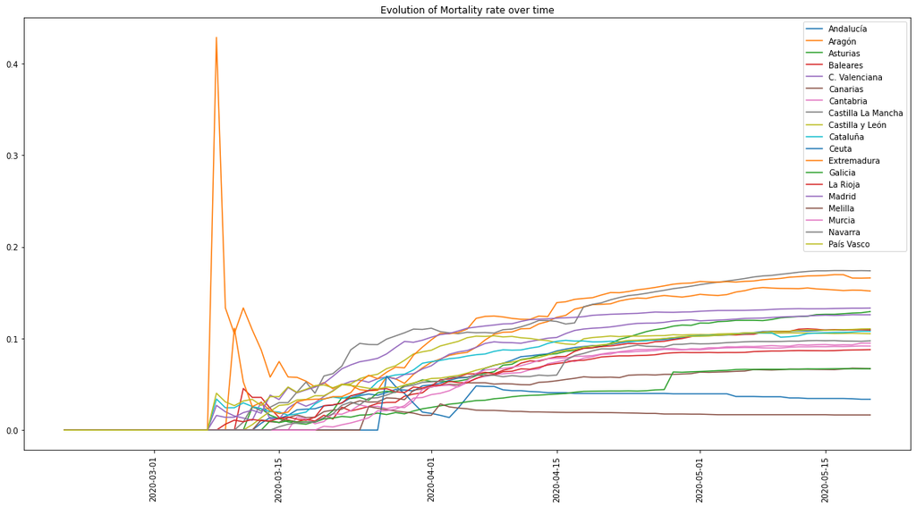

```python
plt.figure(figsize = (20, 10))

for ccaa in sorted(list(df["CCAA"].unique())):

    x = df["DATE"].unique()
    y = df[df["CCAA"] == ccaa]["Mortality_rate"]

    plt.plot(x, y, label = ccaa)
    plt.title("Evolution of Mortality rate over time")
    plt.legend()
    plt.xticks(rotation=90)
```

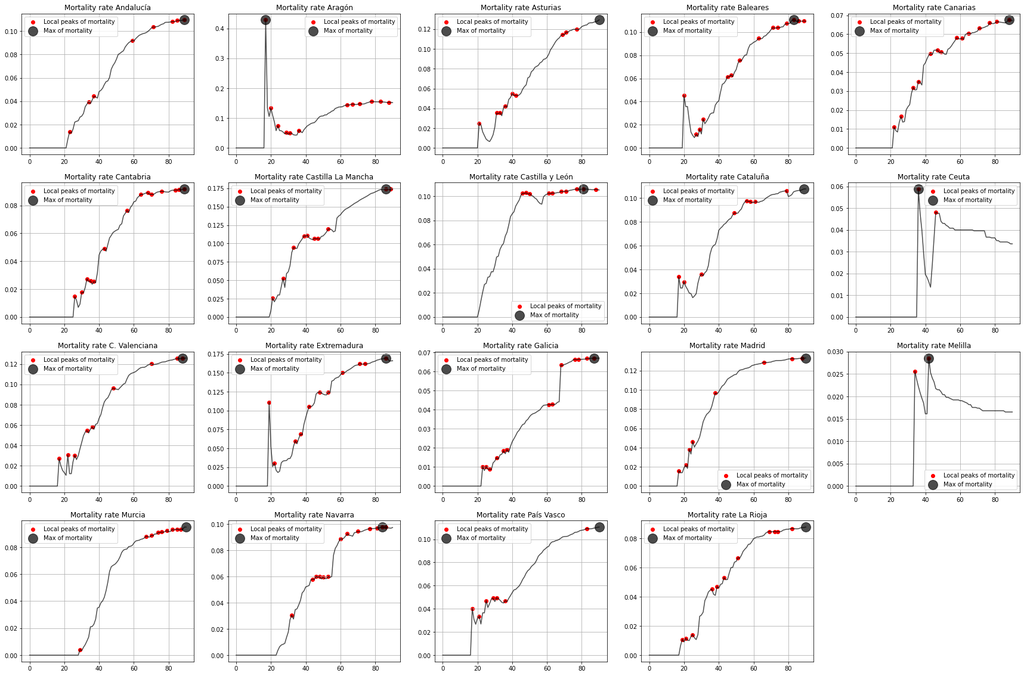

```python
x = [day for day in range(len(df["DATE"].unique()))]

fig, axes = plt.subplots(nrows=4, ncols=5, figsize=(30,20))
# plt.setp(axes, ylim=(0 ,max(df["Mortality rate"])))
ccaas = list(df["CCAA"].unique())

i = 0

for col_axes in axes:
    for ax in col_axes:
        if i < len(ccaas):
            ccaa = ccaas[i]
            y = df[df["CCAA"] == ccaa]["Mortality_rate"].values

            ipeaks, _ = find_peaks(y)

            ax.plot(x, y, color = "k", alpha = 0.7)
            ax.scatter(ipeaks, np.array(y)[ipeaks], color = "red", label = "Local peaks of mortality")
            ax.scatter(x[list(y).index(np.max(y))], np.max(y), color = "k", marker = "o", alpha = 0.7, s = 250, label = "Max of mortality")

            ax.set_title("Mortality rate {}".format(ccaa))
            ax.legend()
            ax.grid()
            i += 1

fig.delaxes(axes[3, 4])
```

create the pivot table of total cases

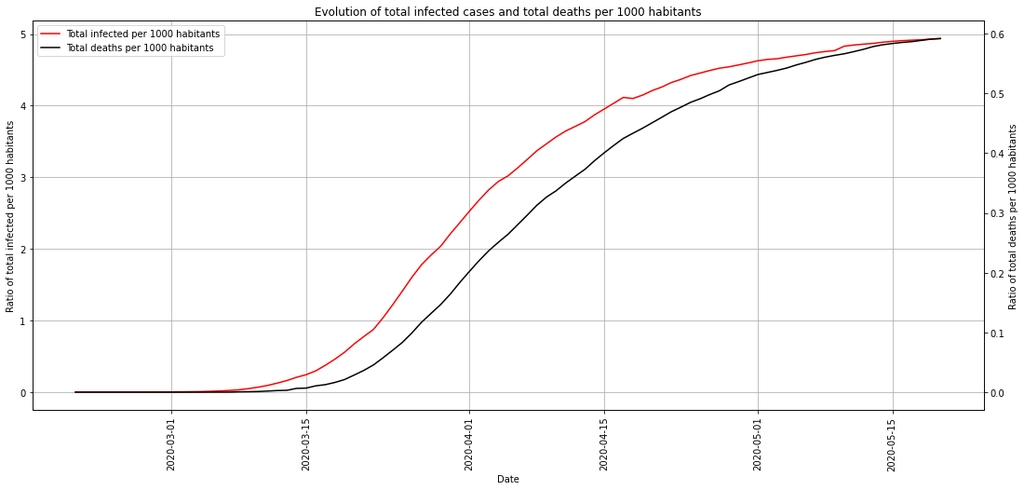

```python
total_df = df.set_index("DATE").resample("D")[["TOTAL_INFECTED", "REQUIERED_HOSPITALIZATION", "REQUIERED_ADVANCED_CARE", "TOTAL_DEATHS","Population"]].sum()
total_df = total_df[total_df["Population"] > 0]
total_df["TOTAL_INFECTED_1000H"] = total_df["TOTAL_INFECTED"]/(total_df["Population"]/1000)
total_df["TOTAL_DEATHS_1000H"] = total_df["TOTAL_DEATHS"]/(total_df["Population"]/1000)

# get the data
x = list(total_df.index)
y_1 = list(total_df["TOTAL_INFECTED_1000H"]) # 1 axis
y_2 = list(total_df["TOTAL_DEATHS_1000H"]) # 2 axis

# create the figures
fig, ax = plt.subplots(figsize = (15, 7))
plot1 = ax.plot(x, y_1, color = "r", label = "Total infected per 1000 habitants") # plot the first data
plt.xticks(rotation=90) # rotate the date

ax2 = ax.twinx() # create a secondary axis
plot2 = ax2.plot(x, y_2, color = "k", label = "Total deaths per 1000 habitants") # plot the second data
fig.tight_layout()
plt.title("Evolution of total infected cases and total deaths per 1000 habitants")

# create a common legend
lns = plot1 + plot2
labs = [l.get_label() for l in lns]
ax.legend(lns, labs, loc=0)

# prettify
ax.grid()
ax.set_xlabel("Date")
ax.set_ylabel("Ratio of total infected per 1000 habitants")
ax2.set_ylabel("Ratio of total deaths per 1000 habitants")
```

## **8 of March manifestation**

On 8 of March, the goverment allowed a massive manifestationa all over the country for the international womens day.

By that time, there where already some informed cases, but, we only know what we know. Now, since the virus need between 7 - 14 days to incubate in your body, this means that a person who was on the manifestation and begin to have syntoms after 7 - 14 days is likely that was already infected or got infected. Let's make this shift in infected cases and see the result.

```python
total_df["SHIFT_7_DAYS"] = total_df["TOTAL_INFECTED"].shift(-7)
total_df["SHIFT_14_DAYS"] = total_df["TOTAL_INFECTED"].shift(-14)
```

### Known infected cases vs 'Real Cases' with a 1 and 2 week shift

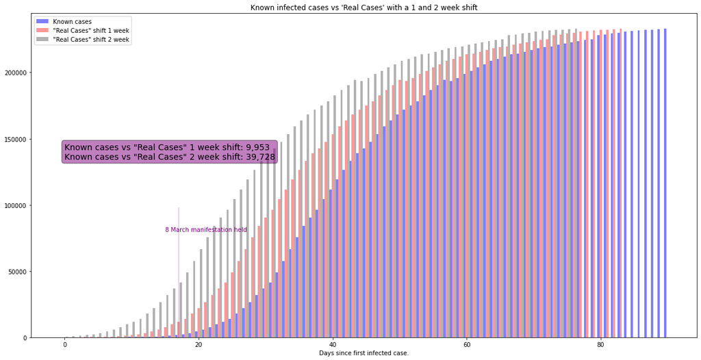

```python
x = np.array([x for x in range(len(total_df.index))])
y_informed = total_df["TOTAL_INFECTED"]
y_real_7_days = total_df["SHIFT_7_DAYS"]
y_real_14_days = total_df["SHIFT_14_DAYS"]
width = np.min(np.diff(x))/3

fig = plt.figure(figsize = (20, 10))

ax = fig.add_subplot(111)
ax.bar(x - width, y_informed, width, color = 'b', label = 'Known cases', alpha = 0.5)
ax.bar(x, y_real_7_days, width, color = 'r', label = '"Real Cases" shift 1 week', alpha = 0.4)
ax.bar(x + width, y_real_14_days, width, color='k', label = '"Real Cases" shift 2 week', alpha = 0.3)
ax.set_xlabel('Days since first infected case.')

plt.title("Known infected cases vs 'Real Cases' with a 1 and 2 week shift")
plt.axvline(x=17, lw = 1, alpha = 0.3, ymax = 0.4, color = "purple")
plt.annotate("8 March manifestation held", xy= (15, 80000), color = "purple")

textstr = '\n'.join((
    r'Known cases vs "Real Cases" 1 week shift: {:,.0f}'.format(total_df.iloc[17]["SHIFT_7_DAYS"] - total_df.iloc[17]["TOTAL_INFECTED"]),
    r'Known cases vs "Real Cases" 2 week shift: {:,.0f}'.format(total_df.iloc[17]["SHIFT_14_DAYS"] - total_df.iloc[17]["TOTAL_INFECTED"])))

props = dict(boxstyle='round', facecolor='purple', alpha=0.5)

# place a text box in upper left in axes coords
ax.text(0.05, 0.6, textstr, transform=ax.transAxes, fontsize=14,
        verticalalignment='top', bbox=props)

plt.legend()
```

### Mortality rate by region

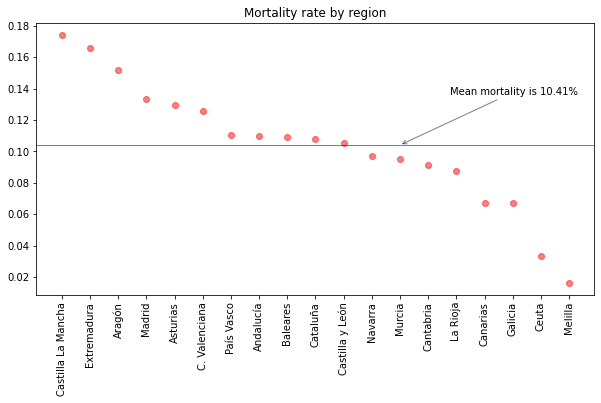

```python
short_df = df[df["DATE"] == max(df["DATE"])][["CCAA", "Mortality_rate"]].sort_values("Mortality_rate", ascending = False)
x = short_df["CCAA"]
y = short_df["Mortality_rate"]

mean_y = np.mean(y)
mean_y

plt.figure(figsize = (10, 5))
plt.scatter(x, y, c= "red", alpha = 0.5)
plt.title("Mortality rate by region")

plt.xticks(rotation=90)
plt.axhline(mean_y, c = "k", alpha = 0.5, lw = 1)
plt.annotate('Mean mortality is {}%'.format(round(mean_y * 100, 2)),
             xy=(12, mean_y),
             xycoords='data',
             xytext=(50, 50),
             textcoords='offset points',
             arrowprops=dict(arrowstyle="->", color = "k", alpha = 0.5),
             color = "k")
```

## General Analysis over the time

### Data Load

```python
infected = pd.read_csv('ccaa_covid19_casos_long.csv')
uci_beds = pd.read_csv('ccaa_camas_uci_2017.csv')
recovered = pd.read_csv('ccaa_covid19_altas_long.csv')
death = pd.read_csv('ccaa_covid19_fallecidos_long.csv')
hospitalized = pd.read_csv('ccaa_covid19_hospitalizados_long.csv')
masks = pd.read_csv('ccaa_covid19_mascarillas.csv')
uci = pd.read_csv('ccaa_covid19_uci_long.csv')
national = pd.read_csv('nacional_covid19.csv')
age_range = pd.read_csv('nacional_covid19_rango_edad.csv')
gdf = gpd.read_file('shapefiles_ccaa_espana.geojson')
```

Coordinates for mapping each CCAA

```python
locations = {'Andalucía':[37.38,-5.97],
            'Aragón':[41.64,-0.88],
            'Asturias':[43.36,-5.85],
            'Baleares':[39.57,2.65],
            'Canarias':[28.09,-15.41],
            'Cantabria':[43.46,-3.8],
            'Castilla La Mancha':[38.98,-3.92],
            'Castilla y León':[41.65,-4.77],
            'Cataluña':[41.39,2.17],
            'Ceuta':[35.89,-5.34],
            'C. Valenciana':[39.37,-0.8],
            'Extremadura':[39.71,-6.16],
            'Galicia':[43.12,-8.46],
            'Madrid':[40.49,-3.71],
            'Melilla':[35.29,-2.95],
            'Murcia':[38.00,-1.48],
            'Navarra':[42.66,-1.64],
            'País Vasco':[43.23,-2.85],
            'La Rioja':[42.27,-2.51]}
```

```python
def dateplot(x, y, **kwargs):
    ax = plt.gca()
    data = kwargs.pop("data")
    data.plot(x=x, y=y, ax=ax, grid=False, **kwargs)
```

```python
infected['fecha'] = pd.to_datetime(infected['fecha'])
hospitalized['fecha'] = pd.to_datetime(hospitalized['fecha'])
uci['fecha'] = pd.to_datetime(uci['fecha'])
recovered['fecha'] = pd.to_datetime(recovered['fecha'])
death['fecha'] = pd.to_datetime(death['fecha'])
```

As the following variables follow an exponential line,the following plots will be displayed using logarithmic scale in order to analyze the lineal trend.

### Infected over time

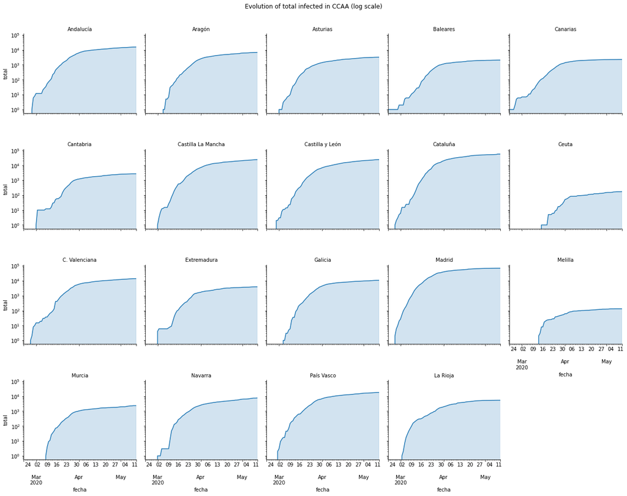

```python
infected = infected[infected['CCAA']!= 'Total']
g = sns.FacetGrid(infected, col="CCAA", col_wrap=5, height=3.5)
g = g.map_dataframe(dateplot, "fecha", "total").set(yscale='log')
g = g.map(plt.fill_between, 'fecha', 'total', alpha=0.2).set_titles("{col_name} CCAA")
g = g.set_titles("{col_name}")
plt.subplots_adjust(top=0.92)
g = g.fig.suptitle('Evolution of total infected in CCAA (log scale)')
```

### ICU over time

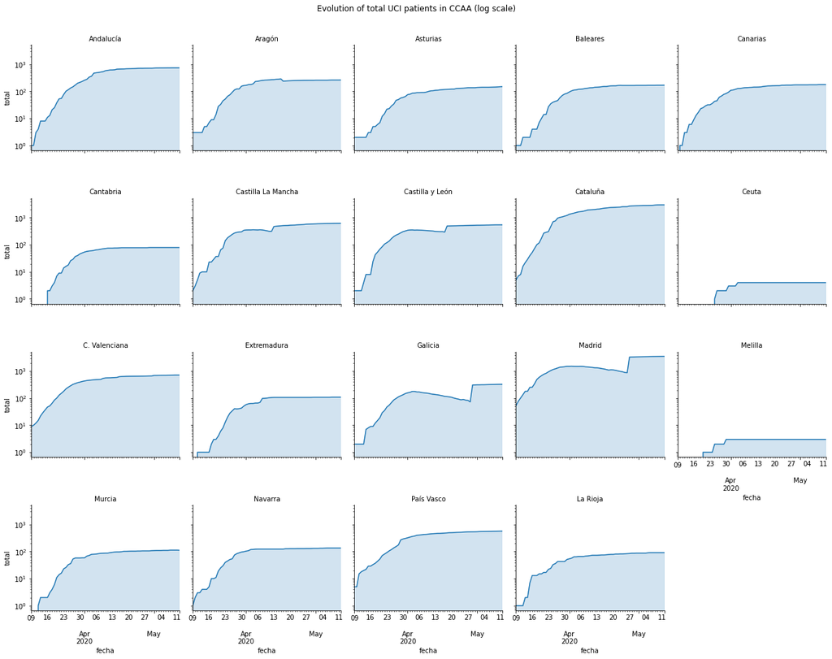

```python
uci = uci[uci['CCAA']!= 'Total']
g = sns.FacetGrid(uci, col="CCAA", col_wrap=5, height=3.5)
g = g.map_dataframe(dateplot, "fecha", "total").set(yscale='log')
g = g.map(plt.fill_between, 'fecha', 'total', alpha=0.2).set_titles("{col_name} CCAA")
g = g.set_titles("{col_name}")
plt.subplots_adjust(top=0.92)
g = g.fig.suptitle('Evolution of total UCI patients in CCAA (log scale)')
```

### Hospitalized over time

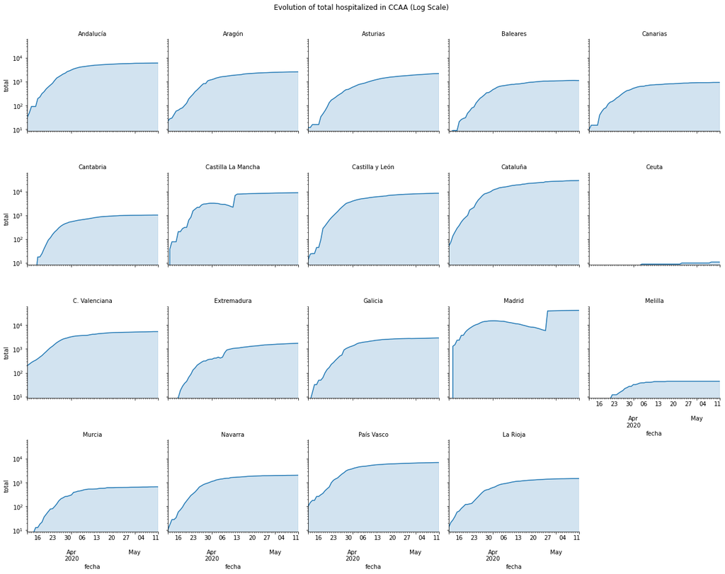

```python
hospitalized = hospitalized[hospitalized['CCAA']!= 'Total']
g = sns.FacetGrid(hospitalized, col="CCAA", col_wrap=5, height=3.5)
g = g.map_dataframe(dateplot, "fecha", "total").set(yscale='log')
g = g.map(plt.fill_between, 'fecha', 'total', alpha=0.2).set_titles("{col_name} CCAA")
g = g.set_titles("{col_name}")
plt.subplots_adjust(top=0.92)
g = g.fig.suptitle('Evolution of total hospitalized in CCAA (Log Scale) ')
```

### Recovered over time

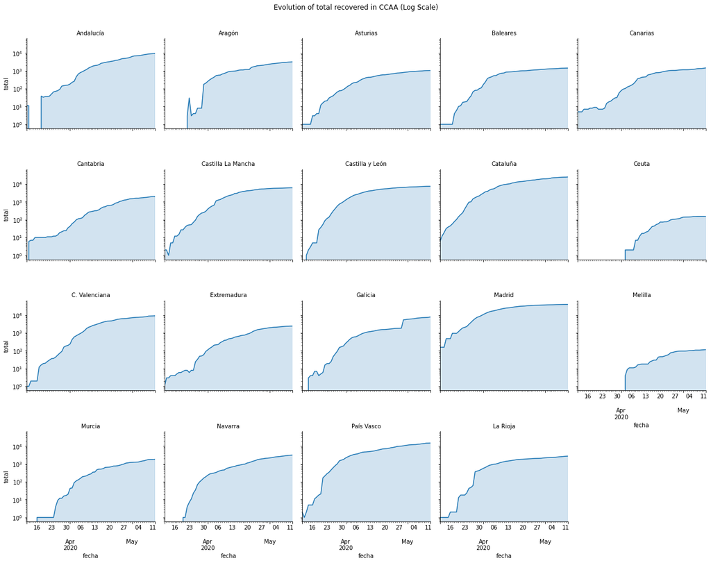

```python
recovered = recovered[recovered['CCAA']!= 'Total']
g = sns.FacetGrid(recovered, col="CCAA", col_wrap=5, height=3.5)
g = g.map_dataframe(dateplot, "fecha", "total").set(yscale='log')
g = g.map(plt.fill_between, 'fecha', 'total', alpha=0.2).set_titles("{col_name} CCAA")
g = g.set_titles("{col_name}")
plt.subplots_adjust(top=0.92)
g = g.fig.suptitle('Evolution of total recovered in CCAA (Log Scale)')
```

### Deaths over time

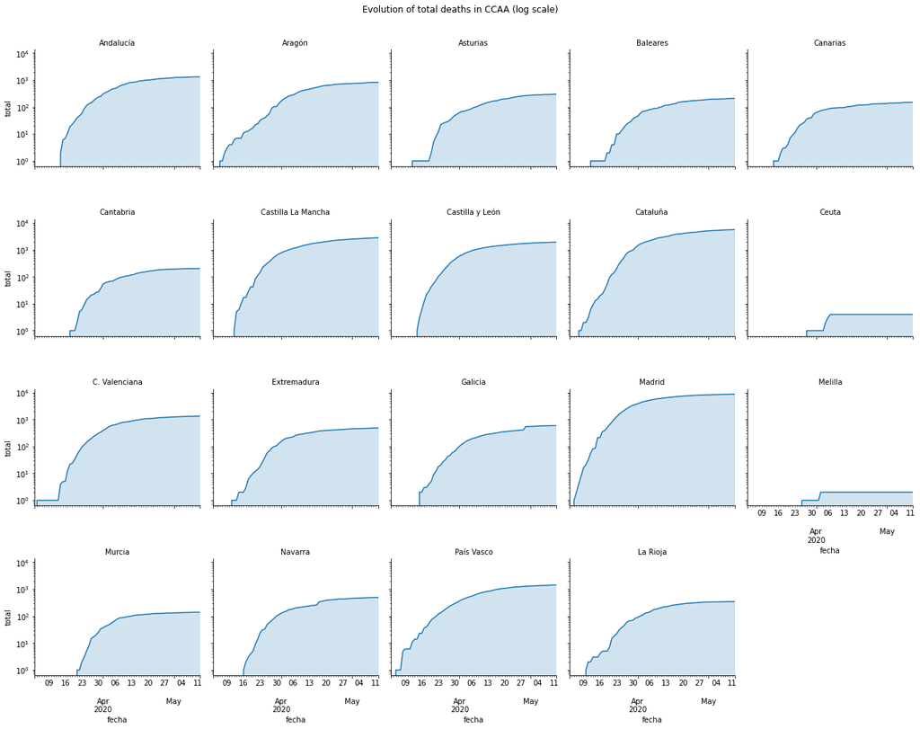

```python
death = death[death['CCAA']!= 'Total']
g = sns.FacetGrid(death, col="CCAA", col_wrap=5, height=3.5)
g = g.map_dataframe(dateplot, "fecha", "total").set(yscale='log')
g = g.map(plt.fill_between, 'fecha', 'total', alpha=0.2).set_titles("{col_name} CCAA")
g = g.set_titles("{col_name}")
plt.subplots_adjust(top=0.92)
g = g.fig.suptitle('Evolution of total deaths in CCAA (log scale)')
```

## Patient Analysis

As a first aproach, I will compare the effects of COVID-19 in each age group without taking into account gender.

```python
age_range= age_range[age_range['rango_edad']!='Total']
age_range= age_range[age_range['rango_edad']!='80 y +']
no_gender = age_range[age_range['sexo']=='ambos']
```

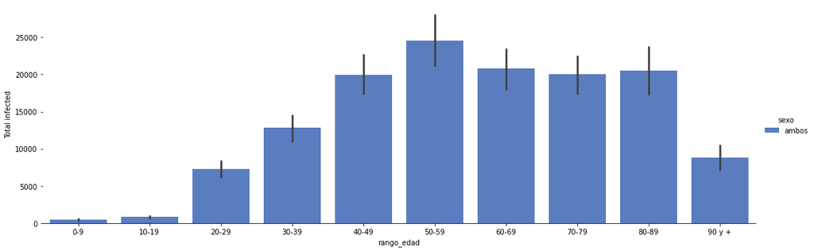

```python
g = sns.catplot(x="rango_edad", y="casos_confirmados", hue="sexo", data=no_gender, kind="bar", height=5,aspect=3,palette="muted")
g.despine(left=True)
g.set_ylabels("Total infected")
```

```python
last = age_range[age_range.iloc[:,0]== age_range.iloc[:,0].max()]
```

In case dataframe format is wrong:

```python
for i in range(last['ingresos_uci'].shape[0]):
    if last.iloc[i,5] == 'i':
        last.iloc[i,5] = 0

last['ingresos_uci']= last['ingresos_uci'].astype(int)
```

In order to compare between different categories, we should normalize the data:

```python
last['casos_confirmados'] = last['casos_confirmados'] / np.linalg.norm(last['casos_confirmados'])
last['hospitalizados'] = last['hospitalizados'] / np.linalg.norm(last['hospitalizados'])
last['ingresos_uci'] = last['ingresos_uci'] / np.linalg.norm(last['ingresos_uci'])
last['fallecidos'] = last['fallecidos'] / np.linalg.norm(last['fallecidos'])
```

```python
last_ambos = last[last['sexo']=='ambos']
last_gender = last[last['sexo']!='ambos']
```

### COVID-19 vs age groups

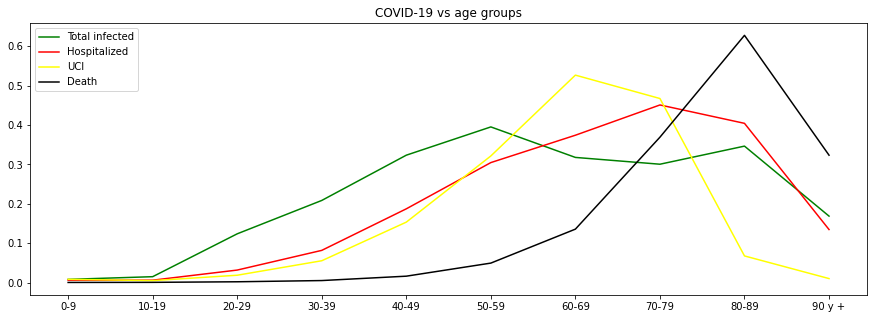

```python
plt.figure(figsize=(15,5))
plt.plot(last_ambos['rango_edad'], last_ambos['casos_confirmados'],color = 'green',label='Total infected')
plt.plot(last_ambos['rango_edad'], last_ambos['hospitalizados'],color = 'red',label='Hospitalized')
plt.plot( last_ambos['rango_edad'], last_ambos['ingresos_uci'],color = 'yellow',label='UCI')
plt.plot( last_ambos['rango_edad'], last_ambos['fallecidos'],color = 'black',label='Death')
plt.title('COVID-19 vs age groups')
plt.legend()
```

The results are as expected. virus affects mostly older people. We can see that the death´s curve peak is around 80-89yo. The most surprising result is the "Total infected" line as the 'peak' goes from 40 to 80 years whick means the disease is present in most of the population.

### COVID-19 vs Gender

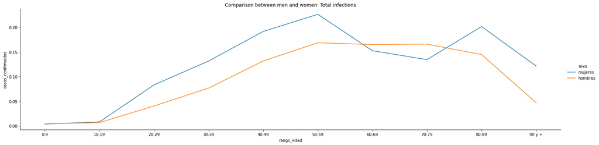

```python
plt.figure(figsize= (10,5))
sns.relplot(x='rango_edad',y ='casos_confirmados', hue = 'sexo',kind='line',data = last_gender,height=5,aspect=4)
plt.title('Comparison between men and women: Total infections')
```

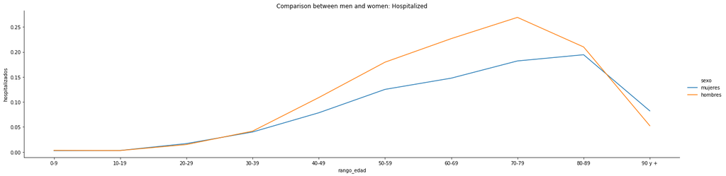

```python
plt.figure(figsize= (10,5))
sns.relplot(x='rango_edad',y ='hospitalizados', hue = 'sexo',kind='line',data = last_gender,height=5,aspect=4)
plt.title('Comparison between men and women: Hospitalized')
```

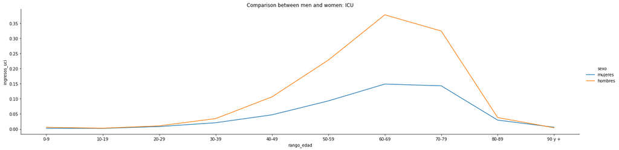

```python
plt.figure(figsize= (10,5))
sns.relplot(x='rango_edad',y ='ingresos_uci', hue = 'sexo',kind='line',data = last_gender,height=5,aspect=4)
plt.title('Comparison between men and women: ICU')
```

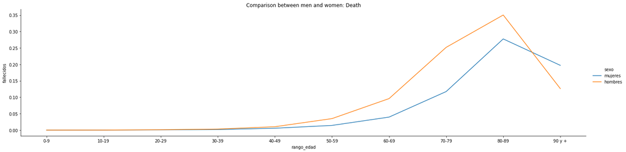

```python
plt.figure(figsize= (10,5))
sns.relplot(x='rango_edad',y ='fallecidos', hue = 'sexo',kind='line',data = last_gender,height=5,aspect=4)
plt.title('Comparison between men and women: Death')
```